# **1. What is CNN?**

CNN which is called as Convolutional Neural Network is majorly used for image classification. It is basically ANN but with some additional layers at the beginning. Some other domains where CNN is used are Scene labelling, object detection, face recognition, etc.

# **2. Structure of CNN?**

CNN is made up of 4 layers namely:

1. Input layer
2. Convolution layer
3. Pooling layer
4. Fully connected layer

# **3. How does CNN work?**

Image is made up of pixelated planes stacked on to each other. There are 3 planes Red, Green & Blue which are stacked together in a 3 dimensional space. So one plane has numerous amount of pixels depending upon the image dimensions. Each pixel cell carries a value from 0 to 255, 255 being the brightest of the colour plane and 0 being the darkest. One thing to remember here is that, Image being an unstructured data, is always passed as an array to the model.

Look at the images below to understand the concept more better.

```python
from google.colab import files
from IPython.display import Image
```

```python
uploaded = files.upload()
```

Upload widget is only available when the cell has been executed in the current browser session. Please rerun this cell to enable.

```
Saving RGB_plane.jpg to RGB_plane.jpg
```

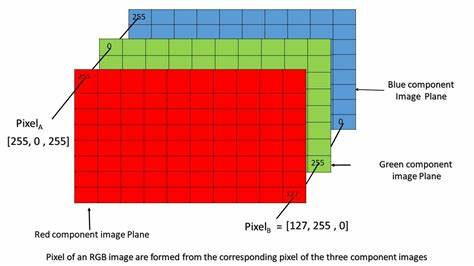

```python
Image('RGB_plane.jpg')
```

```python
uploaded = files.upload()
```

Upload widget is only available when the cell has been executed in the current browser session. Please rerun this cell to enable.

```
Saving CNN_structure_2.png to CNN_structure_2.png
```

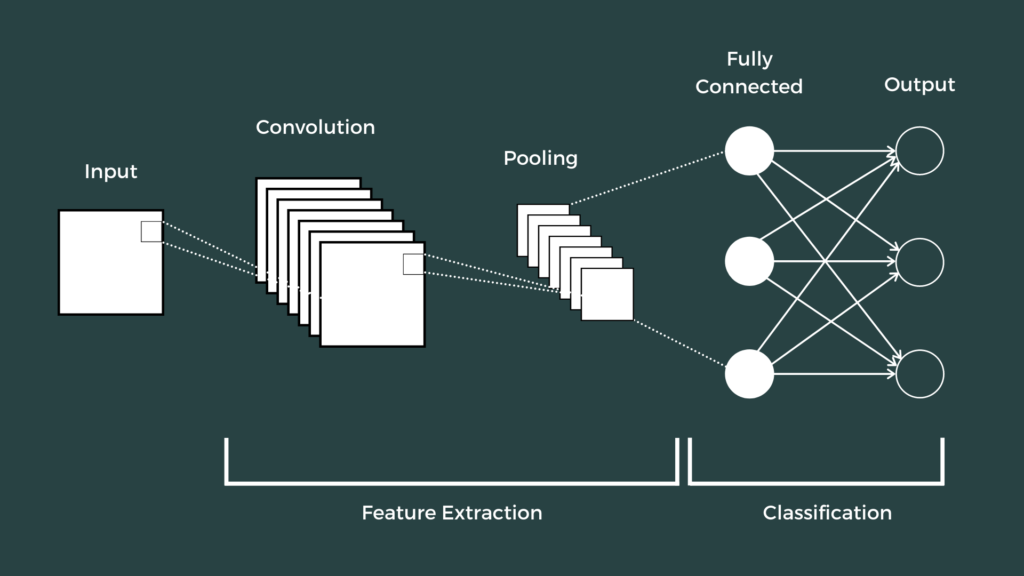

```python
Image('CNN_structure_2.png', width = 800)
```

# **4. How does Convolution layer work?**

A Convolution layer make use of matrix multiplication to make a convoluted image from a pixelated array. The convoluted image is smaller in dimension and contains only important pixels.

There's another concept called stride which one needs to know. So while doing matrix multiplication if the pixelated image is moving 1 pixel at a time then the stride= 1, if the pixelated image is moving 2 pixels at a time, then the stride = 2.

So Stride here is a hyperparameter. If one keeps stride=2 (more) then the model will take less time to train, however the extracted information will be less. On the contrary if stride=1 (less) then the model will take more time to train but the information extracted will be more. So, it is important to use optimum amount of Stride.

```python
uploaded = files.upload()
```

Upload widget is only available when the cell has been executed in the current browser session. Please rerun this cell to enable.

```
Saving CNN_convolution.png to CNN_convolution.png
```

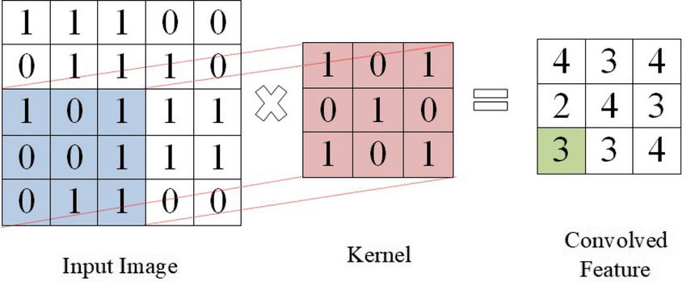

```python
Image('CNN_convolution.png', width = 600)
```

# **5. How does Pooling layer work?**

Pooling layer reduces the amount of information extracted in Convolution layer even further to keep only the most important pixels. So technically it reduces the feature size even further while retaining the most important information. The two common functions used in Pooling layer are:

1. Average pooling
2. Max pooling

**In Average pooling we calculate the average/mean of each patch on the feature map.**

**In Max pooling we calculate the maximum value for each patch on the feature map.**

Look at the image below to understand it more better.

```python
uploaded = files.upload()
```

Upload widget is only available when the cell has been executed in the current browser session. Please rerun this cell to enable.

```
Saving CNN_pooling.png to CNN_pooling.png
```

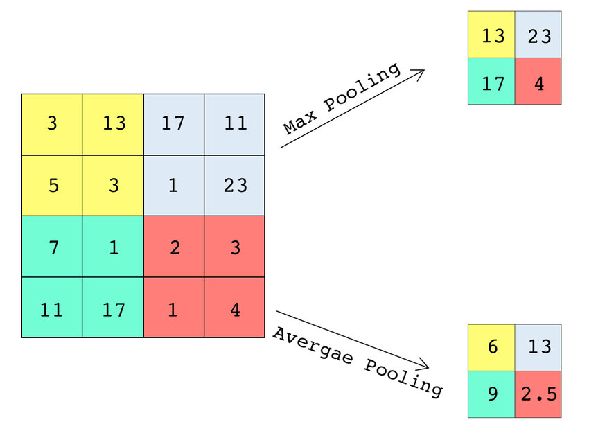

```python
Image('CNN_pooling.png', width = 600)
```

# **6. What is Fully connected layer?**

A Fully connected layer is the layer where the output from pooling layer is flattened up into a vector array. It is then passed on to neurons in the i/p layer, followed by transformations in dense layer and then the classes are predicted on the output layer. To put it briefly, this is where our ANN starts. So, one can say CNN has 2 extra layers Convolution & Pooling layer prior to ANN.

```python
uploaded = files.upload()
```

Upload widget is only available when the cell has been executed in the current browser session. Please rerun this cell to enable.

```
Saving CNN_fully_connecting_layer.png to CNN_fully_connecting_layer.png
```

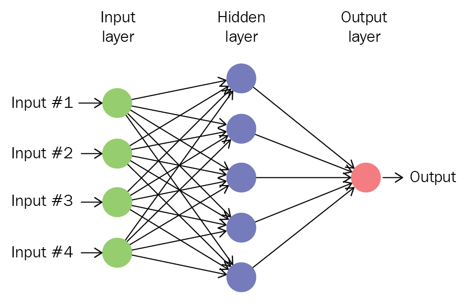

```python
Image('CNN_fully_connecting_layer.png', width = 600)
```

# **Code**

Since we are working on Google colab we have to mount the drive, locate the folder and extract the dataset first.

While mounting the drive, Colab will ask for permissions to access the Google drive, so do grant it.

To locate the folder, first you have to make a folder in the drive first. Once done, run this command.

```python
# Mount the drive
from google.colab import drive
drive.mount('/content/drive')
```

```python
# Locate the folder
import os
os.chdir('/content/drive/MyDrive/CNN')
```

```python
# Extracting rar files
! pip install patool
import patoolib
patoolib.extract_archive('dataset.rar')
```

```
     ━━━━━━━━━━━━━━━━━━━━━━━━━━━━━━━━━━━━━━━━ 96.0/96.0 kB 1.6 MB/s eta 0:00:00
```

```
INFO patool: Extracting dataset.rar ...
INFO:patool:Extracting dataset.rar ...
INFO patool: running /usr/bin/unrar x -- /content/drive/MyDrive/CNN/dataset.rar
INFO:patool:running /usr/bin/unrar x -- /content/drive/MyDrive/CNN/dataset.rar
INFO patool:     with cwd='./Unpack_nc0nh8ex', input=''
INFO:patool:    with cwd='./Unpack_nc0nh8ex', input=''
INFO patool: ... dataset.rar extracted to `dataset11' (local file exists).
INFO:patool:... dataset.rar extracted to `dataset11' (local file exists).
```

```
'dataset11'
```

Install tensorflow

```python
! pip install tensorflow==2.11
```

[output not shown]

## **1. Importing the libraries**

```python
import tensorflow as tf
from tensorflow.keras import layers, models
from tensorflow.keras. preprocessing.image import ImageDataGenerator
```

## **2. Reading the image & defining it's dimensions**

In the code block below, we are extracting dataset and defining batch size as 32 and image dimensions as 128x128.

```python
# Defining the dimensions of image
train_data_dir = 'dataset'
batch_size = 32
img_size= (128,128)
```

## **3. Generating train & validation (test) data**

We are using ImageDataGenerator function to rescale the image and dividing it into:

train = 80 %

validation (test) = 20% (validation_split = 0.2)

where the batch size and target image size is same as defined above.

'rescale=1./255' parameter is used to rescale the pixel values of the images. In this case, it is dividing all pixel values by 255. This operation scales the pixel values to the range [0, 1], which is typically done to normalize the input data. Normalization helps in improving the convergence of the training process.

```python
# Generating train data
datagen = ImageDataGenerator(rescale=1./255, validation_split= 0.2)

train_generator = datagen.flow_from_directory(
      train_data_dir,
      target_size = img_size,
      batch_size = batch_size,
      class_mode = 'categorical',
      subset = 'training'
    )
```

```
Found 1062 images belonging to 3 classes.
```

```python
# Generating validation data
validation_generator = datagen.flow_from_directory(
    train_data_dir,
    target_size = img_size,
    batch_size = batch_size,
    class_mode = 'categorical',
    subset = 'validation'
)
```

```
Found 264 images belonging to 3 classes.
```

So overall we have got 1062 images in the training set and 264 images in the validation set. The classes here are the 3 image classes from the dataset namely Sea, Building & Forest.

## **4. Creating the model**

There are 2 important things to note down here, the first being, since this is a classification model with more than 2 classes we are using activation function as 'softmax' or else if the classes were 2 we could have used 'sigmoid'.

Second being, we have introduced a Dropout layer between the dense and the output layer to avoid any unnecessary Overfitting of data.

```python
# Creating a Sequential model
model = models.Sequential()

# Adding  32 Convolution &  1 Pooling layer
model.add(layers.Conv2D(32,(3,3),activation = 'relu',input_shape = (128,128,3)))
model.add(layers.MaxPooling2D((2,2)))

# Adding 64 Convolution layers & 1 Pooling layer
model.add(layers.Conv2D(64,(3,3),activation = 'relu'))
model.add(layers.MaxPooling2D((2,2)))

# Adding 128 Convolution layers & 1 Pooling layer
model.add(layers.Conv2D(128,(3,3),activation = 'relu'))
model.add(layers.MaxPooling2D((2,2)))

# Flattening the layer to create a 1D array & passing it as an input.
model.add(layers.Flatten())
model.add(layers.Dense(128,activation = 'relu'))

# Adding a Dropout layer is used to avoid Overfitting & defining o/p layer.
model.add(layers.Dropout(0.5))
model.add(layers.Dense(3,activation = 'softmax'))
```

## **5. Compiling the model**

It is then followed by the traditional steps of ANN. Here, we compile the model on the optimizer 'adam', loss being 'categorical_crossentropy' (since we have a classification dataset) and metrics on which we compile is 'accuracy'.

```python
# Compiling the model
model.compile(optimizer = 'adam', loss='categorical_crossentropy',metrics = ['accuracy'])
```

## **6. Training the model**

We then train & fit the model on training data (train_generator) & validation data (test data). We define the epoch steps as the ratio of train generator samples (1062) divided by batch size (32) which would be 33 steps per epoch. We then define the total number of epochs required (100) followed by validation data & validation steps.

```python
# Training the model
history = model.fit(
    train_generator,
    steps_per_epoch = train_generator.samples // batch_size,
    epochs = 100,
    validation_data = validation_generator,
    validation_steps = validation_generator.samples // batch_size
)
```

## **7. Saving the model**

We then save the model as 'mymodel.h5' so that we can test it anytime in future. To test the model we are going to use UI from gradio, so do install that library as well.

```python
model.save('mymodel.h5')
```

```python
! pip install gradio
```

[output not shown]

## **8. Testing the model**

I have written a sample gradio code to test whether the model is working fine.

```python
import gradio as gr
import tensorflow as tf
import numpy as np

# Load the saved model
model = tf.keras.models.load_model('mymodel.h5')

# Define the labels
labels = ['Buildings', 'Forest', 'Sea']

# Define the image classification function
def classify_image(image):
    # Preprocess the image
    image = np.array(image)
    image = tf.image.resize(image, (128, 128))  # Resize the image to match the input size of the model
    image = tf.expand_dims(image, axis=0)  # Add batch dimension
    image = tf.keras.applications.resnet50.preprocess_input(image)

    # Predict the class
    predictions = model.predict(image).flatten()

    # Get the predicted class label
    predicted_class = labels[np.argmax(predictions)]

    return predicted_class

# Create the Gradio interface directly
interface = gr.Interface(classify_image, "image", "label", title="Image Classifier")

# Launch the interface
interface.launch()
```

```
Setting queue=True in a Colab notebook requires sharing enabled. Setting `share=True` (you can turn this off by setting `share=False` in `launch()` explicitly).

Colab notebook detected. To show errors in colab notebook, set debug=True in launch()
Running on public URL: https://c3d7aec977b51eeca7.gradio.live

This share link expires in 72 hours. For free permanent hosting and GPU upgrades, run `gradio deploy` from Terminal to deploy to Spaces (https://huggingface.co/spaces)
```

[interactive chart not shown]

Since I have written the code in Colab the runtime won't make the UI available everytime on this notebook. I would recommend you to visit my Hugging face profile where the app 'Image Classifier' is running live.

[Hugging face profile](https://huggingface.co/Ninad077)

Enclosed below is the image of how the Image Classifier UI looks like.

```python
uploaded = files.upload()
```

Upload widget is only available when the cell has been executed in the current browser session. Please rerun this cell to enable.

```
Saving Image_Classifier_UI_1.png to Image_Classifier_UI_1.png
```

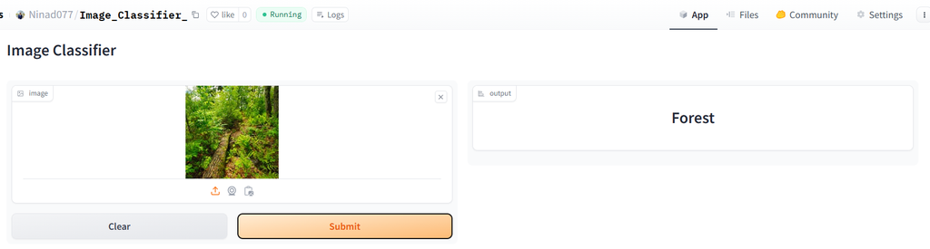

```python
Image('Image_Classifier_UI_1.png')
```

As one can clearly see from the flag window, our interface has correctly classified the image as forest. So, today we studied the core concepts of CNN and understood how one can use CNN to classify images correctly.